# What is Git?

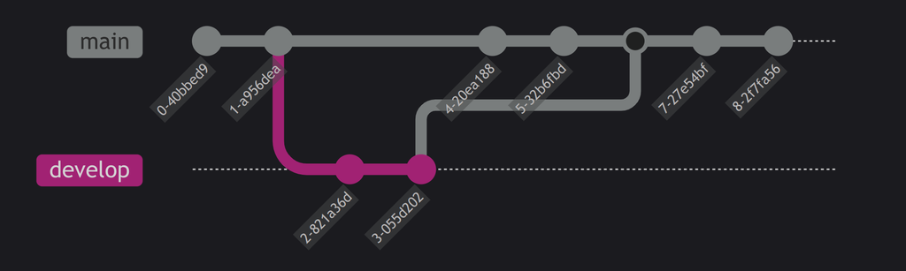

Marie-Hélène Burle

First, we need to answer the question:

# What is version control?

Whenever we work on important documents, we know that we should keep key versions

Example:

- The version of a manuscript that we sent to our supervisor
- The revised version after we addressed their comments
- The revised version after we addressed reviewer comments
- Etc.

It is quite messy…

And inevitably, it leads to this:

[figure not shown]

From [Geek&Poke](http://geek-and-poke.com/)

## Version control systems (VCS) are software that handle versioning effectively

# Which VCS should I use?

Several systems have been developed over the years with various functioning

Then came Git…

## Git

Git is an open source distributed VCS created in 2005 by Linus Torvalds for the versioning of the Linux kernel during its development

In distributed VCS, the full history of projects lives on everybody’s machine—as opposed to being only stored on a central server as was the case with centralized VCS. This allows for offline work and multiple backups

Git also introduced an extremely powerful and light-weight branching system

Git is extremely powerful and almost universally adopted

# How does Git work?

Git saves the history of a project as a series of snapshots

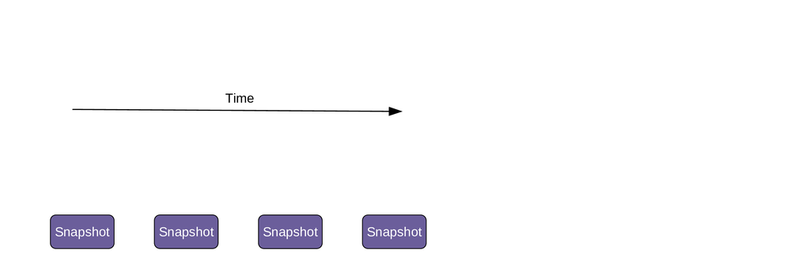

The data is stored as blobs, doesn’t create unnecessary copies (unchanged files are referenced from old blobs), and uses excellent compression

These snapshots are identified by commits

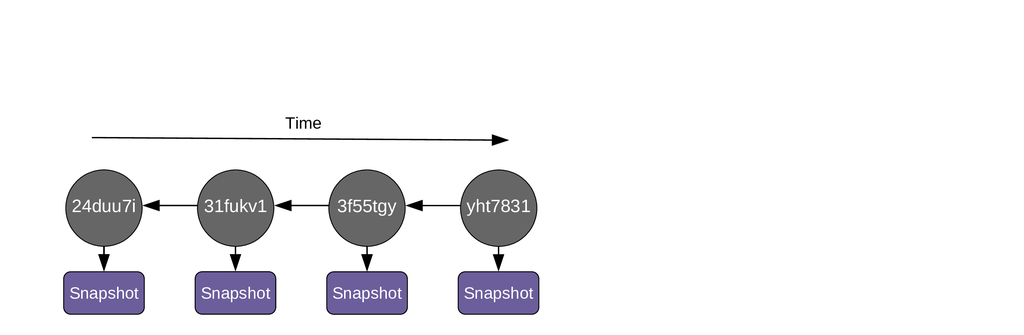

Each commit has a unique *hash* and contains the following metadata:

- Author
- Date and time
- The hash of parent commit(s)
- A descriptive message

When you create the 1<sup>st</sup> commit, a pointer called a *branch* is created and points to it

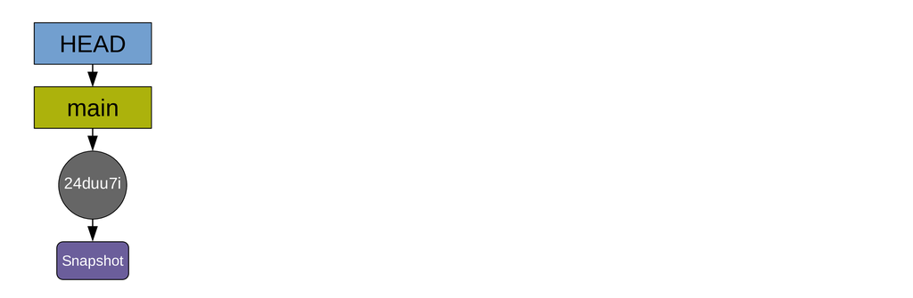

By default, that first branch is called `main`

Another pointer (`HEAD`) points to the branch `main`. `HEAD` indicates where you are in the project history

As you create more commits the pointers `HEAD` and `main` move automatically

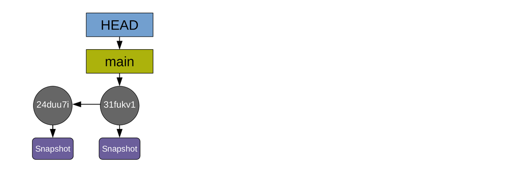

As you create more commits the pointers `HEAD` and `main` move automatically

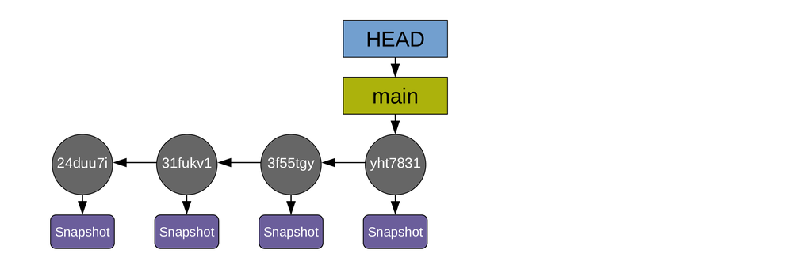

For simplicity, the diagrams can be simplified this way

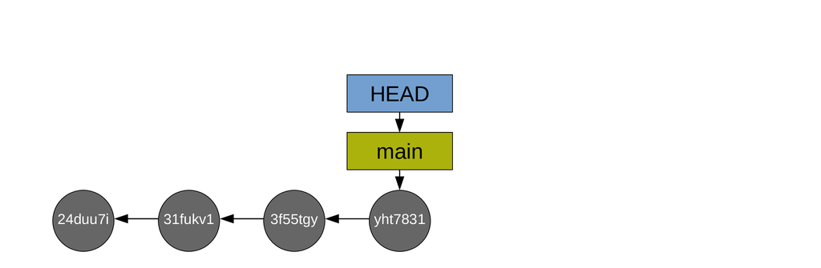

# How can these commits be used?

You can revisit old commits by moving `HEAD` to them

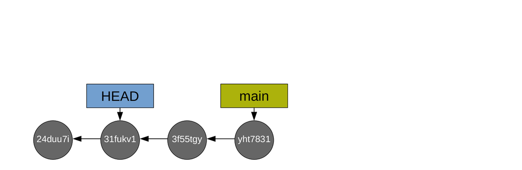

This will uncompress the corresponding snapshot and you can look at the state of your files at that commit before going back to your branch

You can also print the differences between various commits

You can create multiple branches to explore freely and safely

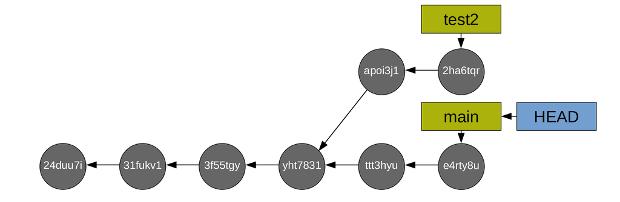

`HEAD` can be moved back and forth between branches

You can merge branches to bring your experiments into your main branch

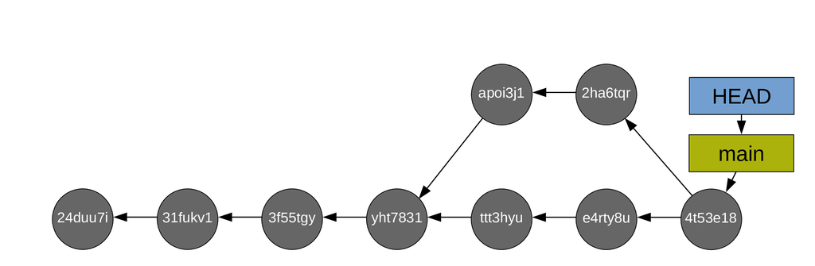

## Time to get started!

[figure not shown]

Back to the course